# Part II

## Interaction Of Loan Original Amount With Other Loan Features.

## by: Dominic Ibamondor Bakantiche

## Investigation Overview

> **Overall goal:**  
> The overall goal of this presentation is to demonstrate how the various loan amounts given to the 112,481 borrowers from 51 states is distributed, and how the loan original amount is influenced by the Prosper Score and borrowers' state, which in turn determines the monthly loan payment to be made every borrower.

> I then followed this with a box plot of the various levels of the Prosper score to understand how they each relate with the loan amount. I was also interested in understanding the relationship between the loan amount and the monthly loan payment made by each of the borrowers, and therefore created a scatter plot which was best suited to grant this.

> To know the relationship between the loan payment and loan amount as distributed across each of the 51 states, I created a facetedgrid of scatter plot, as this was important for me to know which state's borrowers took loans the most, the amounts taken and the magnitude of money repaid back to Prosper on a monthly basis.

> Finally, a scatter plot to understand the distribution of the borrower APR charged on the loan original amount given out, and the corresponding monthly payment was created, and was telling in revealing the range of APR charged on majority of the loans.

## Dataset Overview

> The dataset originally contained information on 113,937 personal loans given by Prosper to borrowers with at least a credit score of 600. After cleaning out an out of range Prosper score, 11.0, the dataset for the investigation now contains 112481 borrowers information. On each loan, there are 81 variables including the loan original amount, borrower rate, stated monthly income, monthly loan payment, employment status, Prosper score, current loan status, and many others. Prosper used a proprietary rating system that considered data points like credit history and debt-to-income ratio to determine the Prosper score of a borrower, which investors relied on to decide whether to fund the loan or not. Most loans were funded within three days, and potential borrowers whose applications were not at least 70% funded expired within 14 days.

## Visualization 1

> The Distribution Of The Loan Original Amount

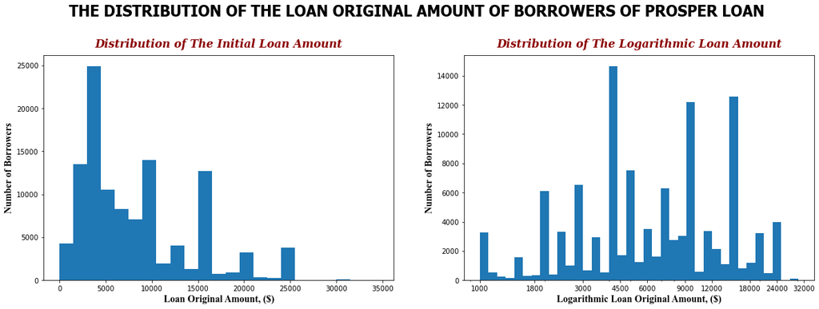

## Visualization 2

> The Relationship Between The Prosper Score And The Loan Original Amount

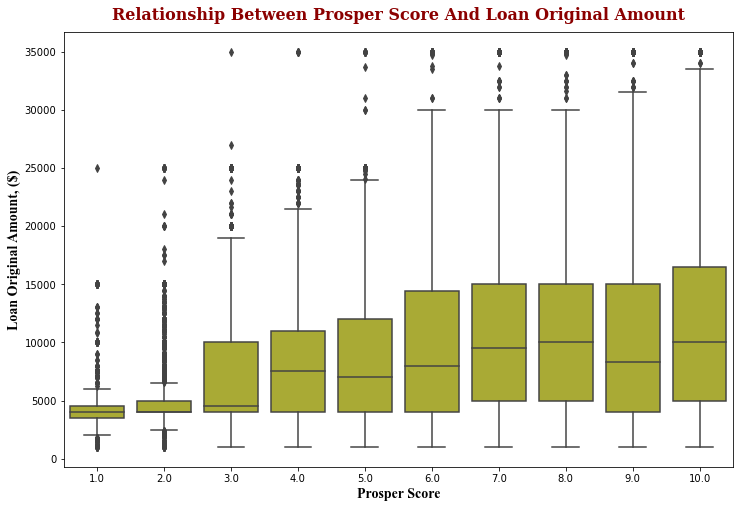

## Visualization 3

> The Relationship Between The Loan Original Amount And The Monthly Loan Payment

A correlation value of 0.9313 shows the direction and a strong positive relationship between the loan original amount and the monthly loan payment. The regression line makes this obvious. The monthly loan payment increased with increasing loan original amount. This phenomenon is more pronounced for monthly loan payments less than 1000 dollars for the range of loan original amount between 0 and 35000 dollars.

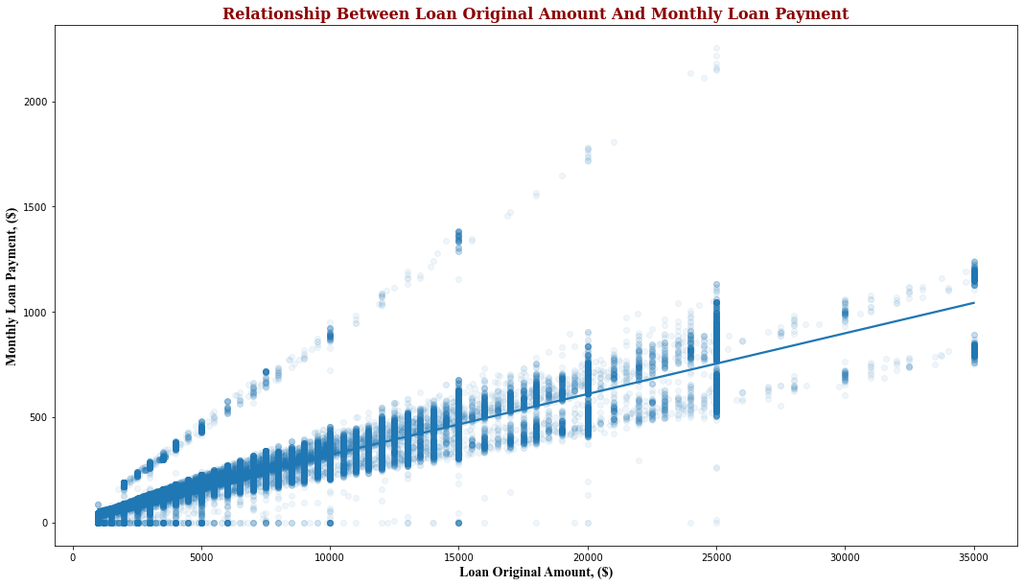

## Visualization 4

> The Interaction Between The Loan Original Amount And The Monthly Loan Payment Across Each Of The 51 States

The loan original amount and the monthly loan payment are strongly correlated across all the states from where borrowers come, despite all the states having varying borrowers population, who also applied and received different loan amounts, and charged different monthly loan payment amounts based on the loan amount received.

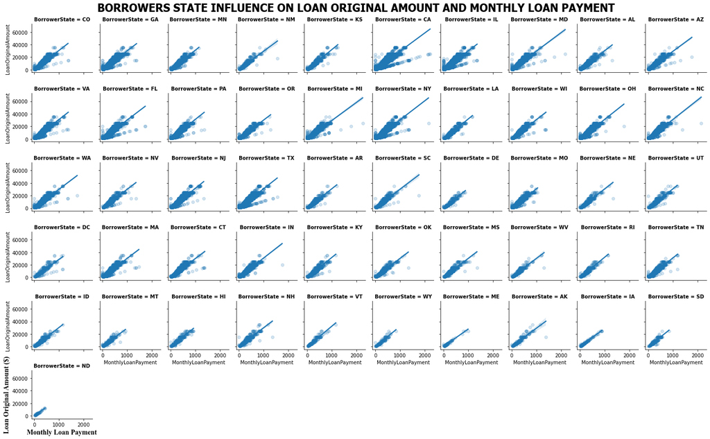

## Visualization 5

> The Interaction Between Loan Original Amount, Monthly Loan Payment And Borrower Annual Percentage Rate (APR)

With the loan original amount correlating strongly with the monthly loan payment, majority of the borrowers had an APR between 0.1 and 0.4 charged on the range of the loan original amount.

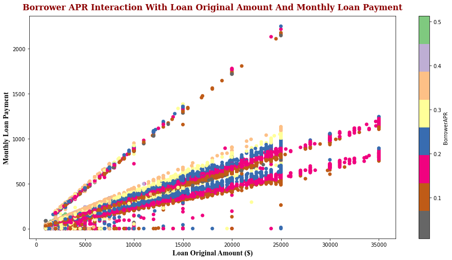